# P1_648241

## 1

En este paso se realizó la exploración inicial de la base de datos, comenzando con la carga del archivo mediante la librería pandas y apoyándose de seaborn y matplotlib para la visualización. Se revisaron las dimensiones, nombres de columnas, tipos de datos y primeras observaciones con el fin de entender la estructura general de la información. Posteriormente, se graficó la variable dependiente “Total UP agropecuaria activas”, tanto en un diagrama de dispersión contra el índice de las observaciones como en un histograma con curva de densidad. Estos gráficos permitieron observar que la mayoría de los municipios presentan valores bajos en el total de unidades de producción, mientras que unos pocos concentran valores muy altos, lo que evidenció desde el inicio la presencia de outliers que podían afectar el análisis posterior.

```
Dimensiones: (2496, 19)

Columnas: ['NOMBRE', 'NOM_MUN', 'ENTIDAD', 'Total UP agropecuaria activas', 'UP Agricolas', 'UP Argri Riego ( R )', 'P UP Riego', 'UP Riego Gravedad (RG)', 'UP RG Canales revestidos', 'UP RG Canales de Tierra', 'UP RG Tubería De Compuerta', 'UP R Por Microaspersión', 'UP R Por Aspersión', 'UP R Por …

Tipos de datos:
NOMBRE                                object
NOM_MUN                               object
ENTIDAD                               object
Total UP agropecuaria activas        float64
UP Agricolas                         float64
UP Argri Riego ( R )                 float64
P UP Riego                           float64
UP Riego Gravedad (RG)               float64
UP RG Canales revestidos             float64
UP RG Canales de Tierra              float64
UP RG Tubería De Compuerta           float64
UP R Por Microaspersión              float64
UP R Por Aspersión                   float64
UP R Por Aspersión Pivote Central    float64
UP R Por Aspersión Avance Frontal    float64
UP R Por Aspersión Cañón             float64
UP R Por Aspersores                  float64
UP R Sistema De Goteo                float64
UP R Mediante Algún Otro Sistema     float64
dtype: object

Primeras observaciones:
   NOMBRE         NOM_MUN           ENTIDAD  Total UP agropecuaria activas  \
0  01 AGS             NaN    Aguascalientes                        19648.0
1  01 AGS  Aguascalientes    Aguascalientes                         3098.0
2  01 AGS        Asientos          Asientos                         3302.0
3  01 AGS        Calvillo          Calvillo                         2659.0
4  01 AGS          CosÃo            CosÃo                         1049.0

   UP Agricolas  UP Argri Riego ( R )  P UP Riego  UP Riego Gravedad (RG)  \
0       18459.0                7394.0   65.472004               58.975418
1        2794.0                 629.0   56.756757               59.943978
2        3238.0                1033.0   75.217812               45.173745
3        2379.0                1524.0   57.611549               43.735763
4        1021.0                 663.0   66.515837               83.219955
```

[output cut: 20 more lines]

```
4                          14.285714                           0.000000

   UP R Por Aspersión Cañón  UP R Por Aspersores  UP R Sistema De Goteo  \
0                 10.573248            82.802548              36.232183
1                 18.518519            62.222222              14.565826
2                  9.230769            89.230769              63.835264
3                 10.158730            91.428571              11.617312
4                  7.142857            78.571429              32.426304

   UP R Mediante Algún Otro Sistema
0                          1.776492
1                          0.280112
2                          0.128700
3                          4.669704
4                          0.680272
```

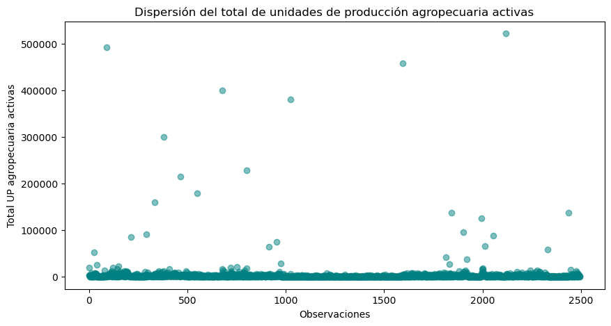

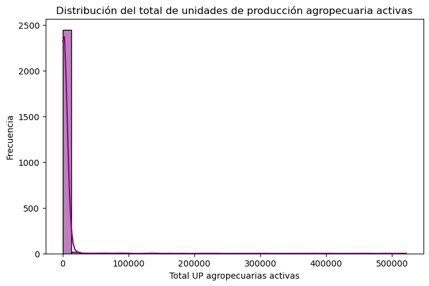

```python
import pandas as pd
import seaborn as sns
import matplotlib.pyplot as plt

df = pd.read_csv("CA2022_Cultivos_Superficie_Produccion.csv", encoding="latin-1")
print("Dimensiones:", df.shape)
print("\nColumnas:", df.columns.tolist())
print("\nTipos de datos:")
print(df.dtypes)
print("\nPrimeras observaciones:")
print(df.head())

plt.figure(figsize=(10,5))
plt.scatter(df.index, df["Total UP agropecuaria activas"], alpha=0.5, color="teal")
plt.xlabel("Observaciones")
plt.ylabel("Total UP agropecuaria activas")
plt.title("Dispersión del total de unidades de producción agropecuaria activas")
plt.show()

plt.figure(figsize=(8,5))
sns.histplot(df["Total UP agropecuaria activas"], bins=40, kde=True, color="purple")
plt.xlabel("Total UP agropecuarias activas")
plt.ylabel("Frecuencia")
plt.title("Distribución del total de unidades de producción agropecuaria activas")
plt.show()
```

Al observar la variable dependiente “Total UP agropecuaria activas”, se identificó que aunque existían valores extremos, la mayoría de los datos se concentraban en un rango relativamente bajo y mostraban una tendencia a relacionarse con las variables de riego. Esta concentración de datos y la posible relación lineal con los predictores iniciales sugirió que una regresión lineal podía ser una buena opción, ya que permite cuantificar cómo cada sistema de riego contribuye al total de unidades de producción y evaluar la significancia estadística de cada variable. Sin embargo, la dispersión y la presencia de outliers también indicaron que el modelo lineal podría no capturar toda la complejidad del fenómeno, por lo que se consideró pertinente comparar con un método no lineal como KNN, capaz de adaptarse mejor a relaciones más complejas o no lineales entre las variables.

## 2

En este paso se aborda la preparación de los datos para garantizar que el análisis sea confiable. Aquí se consideran aspectos como la detección y tratamiento de valores faltantes, la identificación de outliers que puedan alterar los resultados y la revisión de la colinealidad entre variables para evitar redundancias. En general, este apartado se centra en mejorar la calidad de la información disponible, de manera que los modelos que se apliquen más adelante se construyan sobre una base de datos depurada y representativa de la realidad.

### Limpia de huecos

```python
import numpy as np

na_tbl = (df.isna().sum().sort_values(ascending=False)
          .to_frame('faltantes'))
na_tbl['%'] = (na_tbl['faltantes']/len(df))*100
print(na_tbl.head(15))
```

```
                                   faltantes         %
NOM_MUN                                   32  1.282051
UP Agricolas                               4  0.160256
Total UP agropecuaria activas              4  0.160256
UP Argri Riego ( R )                       4  0.160256
NOMBRE                                     0  0.000000
ENTIDAD                                    0  0.000000
P UP Riego                                 0  0.000000
UP Riego Gravedad (RG)                     0  0.000000
UP RG Canales revestidos                   0  0.000000
UP RG Canales de Tierra                    0  0.000000
UP RG Tubería De Compuerta                 0  0.000000
UP R Por Microaspersión                    0  0.000000
UP R Por Aspersión                         0  0.000000
UP R Por Aspersión Pivote Central          0  0.000000
UP R Por Aspersión Avance Frontal          0  0.000000
```

En la revisión de valores faltantes de la base de datos se encontró que la columna NOM_MUN presentaba 32 observaciones nulas, lo que representa un 1.28% del total. Además, las variables UP Agrícolas, Total UP agropecuaria activas y UP Argri Riego (R) tenían cada una 4 valores faltantes, equivalentes a un 0.16% de los registros. El resto de las columnas no presentó huecos y se encontraban completas, por lo que el problema de datos ausentes se concentró únicamente en estas variables.

```python
# Eliminar columnas de identificación que no se usan en el modelo
df = df.drop(columns=["NOM_MUN", "NOMBRE", "ENTIDAD"], errors="ignore")
# Eliminar filas donde falta la variable objetivo
df = df.dropna(subset=["Total UP agropecuaria activas"])

print("Valores faltantes por columna después de limpieza:")
print(df.isna().sum())

print("\nColumnas actuales en el DataFrame:")
print(df.columns.tolist())
```

```
Valores faltantes por columna después de limpieza:
Total UP agropecuaria activas        0
UP Agricolas                         0
UP Argri Riego ( R )                 0
P UP Riego                           0
UP Riego Gravedad (RG)               0
UP RG Canales revestidos             0
UP RG Canales de Tierra              0
UP RG Tubería De Compuerta           0
UP R Por Microaspersión              0
UP R Por Aspersión                   0
UP R Por Aspersión Pivote Central    0
UP R Por Aspersión Avance Frontal    0
UP R Por Aspersión Cañón             0
UP R Por Aspersores                  0
UP R Sistema De Goteo                0
UP R Mediante Algún Otro Sistema     0
dtype: int64

Columnas actuales en el DataFrame:
['Total UP agropecuaria activas', 'UP Agricolas', 'UP Argri Riego ( R )', 'P UP Riego', 'UP Riego Gravedad (RG)', 'UP RG Canales revestidos', 'UP RG Canales de Tierra', 'UP RG Tubería De Compuerta', 'UP R Por Microaspersión', 'UP R Por Aspersión', 'UP R Por Aspersión Pivote Central', 'UP R Por Asper…
```

Para resolver el problema de valores faltantes en la base de datos, se decidió eliminar las columnas de identificación (*NOM_MUN, NOMBRE y ENTIDAD*), ya que estas únicamente funcionan como referencias geográficas y no aportan valor al modelo de regresión. Posteriormente, se eliminaron las filas en las que la variable objetivo Total UP agropecuaria activas presentaba valores nulos, debido a que esta columna es fundamental para el análisis y no resulta adecuado imputar datos en ella. Con estas acciones, el conjunto de datos quedó limpio y sin valores faltantes, manteniendo únicamente las variables relevantes para la construcción del modelo de regresión.

### Outliers

```
Límite inferior: -2700.38
Límite superior: 5618.62
Número de outliers detectados: 190
Tamaño original: (2492, 16)
Tamaño sin outliers: (2302, 16)
```

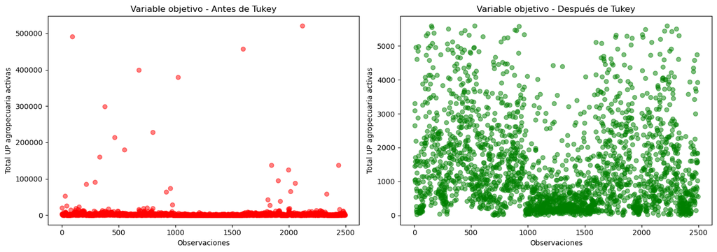

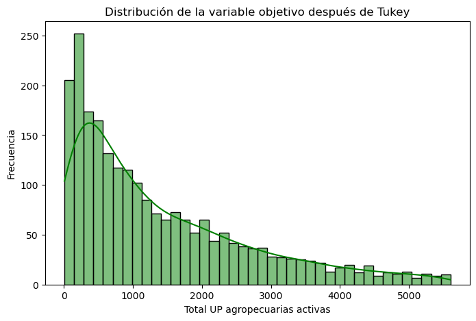

```python
import seaborn as sns

target = "Total UP agropecuaria activas"

Q1 = df[target].quantile(0.25)
Q3 = df[target].quantile(0.75)
IQR = Q3 - Q1
lim_inf = Q1 - 1.5 * IQR
lim_sup = Q3 + 1.5 * IQR

print(f"Límite inferior: {lim_inf:.2f}")
print(f"Límite superior: {lim_sup:.2f}")

outliers = df[(df[target] < lim_inf) | (df[target] > lim_sup)]
print(f"Número de outliers detectados: {outliers.shape[0]}")

df_tukey = df[(df[target] >= lim_inf) & (df[target] <= lim_sup)]

print("Tamaño original:", df.shape)
print("Tamaño sin outliers:", df_tukey.shape)

fig, axes = plt.subplots(1, 2, figsize=(14,5))


axes[0].scatter(df.index, df[target], alpha=0.5, color="red")
axes[0].set_title("Variable objetivo - Antes de Tukey")
axes[0].set_xlabel("Observaciones")
axes[0].set_ylabel(target)

axes[1].scatter(df_tukey.index, df_tukey[target], alpha=0.5, color="green")
axes[1].set_title("Variable objetivo - Después de Tukey")
axes[1].set_xlabel("Observaciones")
axes[1].set_ylabel(target)

plt.tight_layout()
plt.show()

plt.figure(figsize=(8,5))
sns.histplot(df_tukey["Total UP agropecuaria activas"], bins=40, kde=True, color="green")
plt.xlabel("Total UP agropecuarias activas")
plt.ylabel("Frecuencia")
plt.title("Distribución de la variable objetivo después de Tukey")
plt.show()
```

Se detectaron valores atípicos extremos en la variable dependiente mediante el método de Tukey. Estos valores, aunque reales, representaban observaciones desproporcionadas que podían sesgar la regresión. Por ello, se eliminaron los outliers definidos por los límites de Tukey, quedando una distribución más estable para el modelado.

### Colinealidad

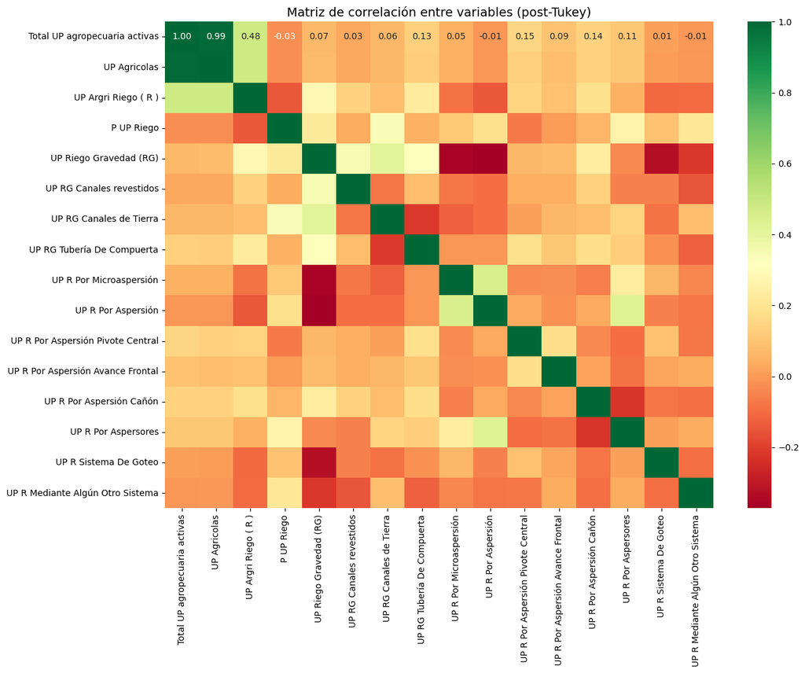

```
Pares más correlacionados:

UP Agricolas                   Total UP agropecuaria activas    0.993310
Total UP agropecuaria activas  UP Agricolas                     0.993310
UP Argri Riego ( R )           UP Agricolas                     0.483596
UP Agricolas                   UP Argri Riego ( R )             0.483596
UP Argri Riego ( R )           Total UP agropecuaria activas    0.481909
Total UP agropecuaria activas  UP Argri Riego ( R )             0.481909
UP R Por Microaspersión        UP R Por Aspersión               0.453323
dtype: float64
```

```python
corr = df_tukey.corr()

plt.figure(figsize=(14,10))
sns.heatmap(corr, annot=True, cmap="RdYlGn", fmt=".2f")
plt.title("Matriz de correlación entre variables (post-Tukey)", fontsize=14)
plt.show()

pairs = (
    corr.where(~np.eye(corr.shape[0], dtype=bool))
        .stack()
        .sort_values(ascending=False)
)

print("Pares más correlacionados:\n")
print(pairs.head(7))
```

```python
base = df_tukey if 'df_tukey' in globals() else df
target = "Total UP agropecuaria activas"
y = base[target].copy()
cols_excluir = {target, "UP Agricolas", "y_winz", "y_log", "es_outlier"} & set(base.columns)
X = base.drop(columns=list(cols_excluir), errors="ignore").select_dtypes(include="number").copy()

# Reporte
print("Columnas seleccionadas como predictoras (X):")
print(list(X.columns))
print("\nVariable objetivo (Y):")
print(target)
```

```
Columnas seleccionadas como predictoras (X):
['UP Argri Riego ( R )', 'P UP Riego', 'UP Riego Gravedad (RG)', 'UP RG Canales revestidos', 'UP RG Canales de Tierra', 'UP RG Tubería De Compuerta', 'UP R Por Microaspersión', 'UP R Por Aspersión', 'UP R Por Aspersión Pivote Central', 'UP R Por Aspersión Avance Frontal', 'UP R Por Aspersión Cañón',…

Variable objetivo (Y):
Total UP agropecuaria activas
```

## 3

En este paso se trabaja con la selección de características, es decir, con la elección de aquellas variables que realmente aportan valor al modelo. El objetivo de este apartado es reducir la dimensionalidad, eliminar predictores irrelevantes o redundantes y quedarse únicamente con las variables que explican mejor la variable de salida. De esta manera, se busca simplificar el modelo, hacerlo más interpretable y mejorar su desempeño al evitar el sobreajuste y centrarse en los factores más significativos.

### Selección de características mediante métodos forward y backward

```python
from sklearn.feature_selection import SequentialFeatureSelector
from sklearn.linear_model import LinearRegression

lin = LinearRegression()

# Selección hacia adelante (forward)
sfs_forward = SequentialFeatureSelector(
    lin, n_features_to_select="auto", direction="forward", cv=5, n_jobs=-1
)
sfs_forward.fit(X, y)
sel_forward = list(X.columns[sfs_forward.get_support()])

print("Variables seleccionadas por Forward:")
print(sel_forward)

# Selección hacia atrás (backward) sobre las elegidas en forward
X_forward = X[sel_forward]

sfs_backward = SequentialFeatureSelector(
    lin, n_features_to_select="auto", direction="backward", cv=5, n_jobs=-1
)
sfs_backward.fit(X_forward, y)
sel_hybrid = list(X_forward.columns[sfs_backward.get_support()])

print("\nVariables finales después de aplicar Backward sobre Forward:")
print(sel_hybrid)
cols_final = sel_hybrid
```

```
Variables seleccionadas por Forward:
['UP Argri Riego ( R )', 'UP R Por Microaspersión', 'UP R Por Aspersión Pivote Central', 'UP R Por Aspersión Avance Frontal', 'UP R Por Aspersión Cañón', 'UP R Por Aspersores', 'UP R Sistema De Goteo']

Variables finales después de aplicar Backward sobre Forward:
['UP Argri Riego ( R )', 'UP R Por Aspersión Pivote Central', 'UP R Por Aspersión Cañón', 'UP R Por Aspersores']
```

La aplicación combinada de los métodos forward y backward permitió depurar el conjunto inicial de predictores y quedarse únicamente con las variables más relevantes para explicar la variable dependiente. Mientras el forward propuso un conjunto amplio de candidatos, el backward refinó esa selección al descartar los predictores menos influyentes, lo que resultó en un modelo más compacto y manejable. Este proceso no solo mejoró la interpretabilidad del modelo, sino que también ayudó a reducir la redundancia y a concentrarse en los factores con mayor impacto sobre el total de unidades agropecuarias activas.

## 4

En este paso se construyen y entrenan los modelos seleccionados, tanto lineal como no lineal, con el fin de analizar su comportamiento y compararlos. Aquí se estiman los coeficientes del modelo lineal y se revisa cuáles de ellos tienen una relación estadísticamente significativa con la variable de respuesta, lo que permite interpretar el efecto de cada predictor. Además, se entrena un modelo no lineal (como KNN) para contrastar el desempeño y observar si capta mejor la variabilidad de los datos. En este apartado se centra en pasar de la preparación de datos a la implementación de los modelos y en la interpretación inicial de sus resultados.

### Modelo Lineal

- **Partir de las variables seleccionadas (X[cols_final])** Usar solo las columnas resultantes del proceso forward→backward reduce ruido, redundancia y varianza del modelo. Así, los coeficientes son más estables y la predicción es menos sensible a multicolinealidad.
- **Separar entrenamiento y prueba (80/20 con train_test_split):** Entrenar con el 80% y reservar el 20% para “datos nunca vistos” evitar fuga de datos. La evaluación en test refleja el desempeño real fuera de muestra. random_state=21 garantiza reproducibilidad.
- **Añadir constante con sm.add_constant:** El intercepto evita forzar que la recta pase por el origen y capta el nivel medio de la respuesta cuando los predictores valen cero. Sin intercepto, los coeficientes se sesgan si la relación no pasa por (0,0).
- **Ajustar con statsmodels.OLS sobre el train solamente:** Se entrena solo con X_tr_sm, y_tr para no “aprender” del conjunto de prueba. Elegimos statsmodels porque, además de ajustar, permite inferencia: p-values, IC al 95%, F-test, R² ajustado. Con eso verificamos qué predictores aportan señal real y no casual.
- **Imprimir summary() y tabla de coeficientes p-values:** El summary() muestra magnitud, dirección y significancia de cada coeficiente. Marcar como “significativo_0.05” formaliza el criterio (p<0.05) y evita mantener variables que no ayudan a generalizar. La inferencia respalda la interpretabilidad y reduce el riesgo de sobreajuste por predictores espurios.
- **Predecir en test y graficar reales vs. predichos:** La dispersión respecto a la diagonal 45° evalúa calibración y error fuera de muestra: puntos cercanos a la línea indican buen ajuste, patrones sistemáticos revelan sesgos o no linealidades que afectan la generalización.

```
                                  OLS Regression Results
=========================================================================================
Dep. Variable:     Total UP agropecuaria activas   R-squared:                       0.258
Model:                                       OLS   Adj. R-squared:                  0.257
Method:                            Least Squares   F-statistic:                     159.9
Date:                           Mon, 08 Sep 2025   Prob (F-statistic):          1.68e-117
Time:                                   05:31:25   Log-Likelihood:                -15523.
No. Observations:                           1841   AIC:                         3.106e+04
Df Residuals:                               1836   BIC:                         3.108e+04
Df Model:                                      4
Covariance Type:                       nonrobust
=====================================================================================================
                                        coef    std err          t      P>|t|      [0.025      0.975]
-----------------------------------------------------------------------------------------------------
const                               793.0521     52.323     15.157      0.000     690.433     895.671
UP Argri Riego ( R )                  1.0625      0.049     21.753      0.000       0.967       1.158
UP R Por Aspersión Pivote Central     5.8988      1.287      4.584      0.000       3.375       8.423
UP R Por Aspersión Cañón              4.0524      1.007      4.025      0.000       2.078       6.027
UP R Por Aspersores                   3.3305      0.665      5.006      0.000       2.026       4.635
==============================================================================
Omnibus:                      450.964   Durbin-Watson:                   2.011
Prob(Omnibus):                  0.000   Jarque-Bera (JB):              900.656
Skew:                           1.450   Prob(JB):                    2.66e-196
Kurtosis:                       4.825   Cond. No.                     1.25e+03
==============================================================================

Notes:
[1] Standard Errors assume that the covariance matrix of the errors is correctly specified.
[2] The condition number is large, 1.25e+03. This might indicate that there are
strong multicollinearity or other numerical problems.
Coeficientes y significancia (modelo lineal OLS):

                            variable  coeficiente  p_value significativo_0.05
0                              const     793.0521   0.0000                 Sí
1               UP Argri Riego ( R )       1.0625   0.0000                 Sí
2  UP R Por Aspersión Pivote Central       5.8988   0.0000                 Sí
3           UP R Por Aspersión Cañón       4.0524   0.0001                 Sí
4                UP R Por Aspersores       3.3305   0.0000                 Sí
```

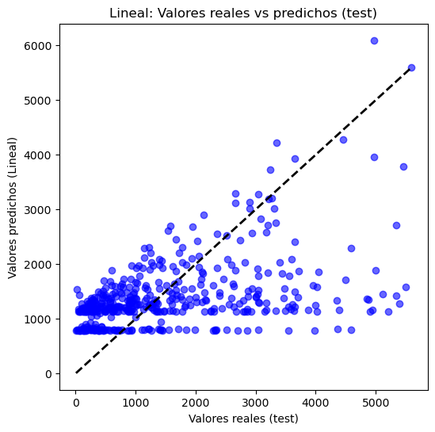

```python
import statsmodels.api as sm
from sklearn.model_selection import train_test_split

X_sel = X[cols_final].copy()
y_sel = y.copy()
X_tr, X_te, y_tr, y_te = train_test_split(X_sel, y_sel, test_size=0.20, random_state=21)
X_tr_sm = sm.add_constant(X_tr)
X_te_sm = sm.add_constant(X_te)
ols = sm.OLS(y_tr, X_tr_sm).fit()
print(ols.summary())
tabla = (
    pd.DataFrame({
        "coeficiente": ols.params,
        "p_value": ols.pvalues
    })
    .rename_axis("variable")
    .reset_index()
)

tabla["coeficiente"] = tabla["coeficiente"].round(4)
tabla["p_value"] = tabla["p_value"].round(4)
tabla["significativo_0.05"] = np.where(tabla["p_value"] < 0.05, "Sí", "No")
print("Coeficientes y significancia (modelo lineal OLS):\n")
print(tabla)

y_te_hat_lin = ols.predict(X_te_sm)
plt.figure(figsize=(6,6))
plt.scatter(y_te, y_te_hat_lin, alpha=0.6, color="blue")
plt.plot([y_te.min(), y_te.max()], [y_te.min(), y_te.max()], 'k--', lw=2)
plt.xlabel("Valores reales (test)")
plt.ylabel("Valores predichos (Lineal)")
plt.title("Lineal: Valores reales vs predichos (test)")
plt.show()
```

Al entrenar el modelo lineal, se imprimieron los coeficientes estimados junto con sus p-values. Se consideró asociación significativa con la respuesta cuando p < 0.05, es decir, cuando se rechaza la hipótesis nula de que el coeficiente es cero. En nuestro caso, las variables seleccionadas (UP Argri Riego (R), UP R por Aspersión Pivote Central, UP R por Aspersión Cañón y UP R por Aspersores) presentan p-values menores a 0.05, por lo que todas muestran una asociación positiva y estadísticamente significativa con el total de unidades de producción agropecuaria activas. Esta conclusión es consistente con los intervalos de confianza al 95%, que no incluyen el cero, reforzando la evidencia de significancia.

### Modelo No Lienal (KNN)

La tabla ordenada por la caída media en R², junto con los intervalos, comunica de forma clara cuáles predictores sostienen el desempeño del KNN y con qué incertidumbre, aportando interpretabilidad aun sin coeficientes.

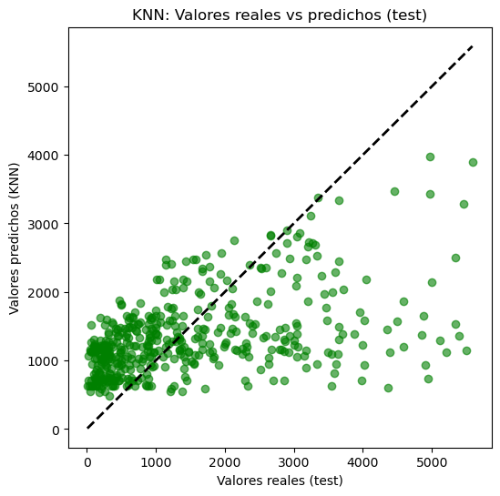

```
Importancia de variables (Permutation Importance) en KNN - Test:
                            variable      R2     std  IC95_inf  IC95_sup  \
0               UP Argri Riego ( R )  0.2715  0.0328    0.2072    0.3358
1                UP R Por Aspersores  0.0413  0.0178    0.0064    0.0763
2  UP R Por Aspersión Pivote Central  0.0133  0.0091   -0.0044    0.0311
3           UP R Por Aspersión Cañón  0.0132  0.0097   -0.0057    0.0322

  significativa
0            Sí
1            Sí
2            No
3            No
```

```python
from sklearn.neighbors import KNeighborsRegressor
from sklearn.pipeline import Pipeline
from sklearn.preprocessing import StandardScaler
from sklearn.inspection import permutation_importance

knn_model = Pipeline([
    ("scaler", StandardScaler()),
    ("knn", KNeighborsRegressor(n_neighbors=51))
])
knn_model.fit(X_tr, y_tr)

y_te_hat_knn = knn_model.predict(X_te)

plt.figure(figsize=(6,6))
plt.scatter(y_te, y_te_hat_knn, alpha=0.6, color="green")
plt.plot([y_te.min(), y_te.max()], [y_te.min(), y_te.max()], 'k--', lw=2)
plt.xlabel("Valores reales (test)")
plt.ylabel("Valores predichos (KNN)")
plt.title("KNN: Valores reales vs predichos (test)")
plt.show()


feature_names = X_tr.columns
perm = permutation_importance(
    knn_model, X_te, y_te,
    n_repeats=50,
    random_state=30,
    scoring="r2"
)

imp_mean = perm.importances_mean
imp_std  = perm.importances_std
lower = imp_mean - 1.96 * imp_std
upper = imp_mean + 1.96 * imp_std
signif = np.where(lower > 0, "Sí", "No")
tabla_imp = (
    pd.DataFrame({
        "variable": feature_names,
        "R2": imp_mean,
        "std": imp_std,
        "IC95_inf": lower,
        "IC95_sup": upper,
        "significativa": signif
    })
    .sort_values("R2", ascending=False)
    .reset_index(drop=True)
)

tabla_imp[["R2","std","IC95_inf","IC95_sup"]] = \
    tabla_imp[["R2","std","IC95_inf","IC95_sup"]].round(4)

print("\nImportancia de variables (Permutation Importance) en KNN - Test:")
print(tabla_imp)
```

En el modelo KNN no se estiman coeficientes, por lo que se utilizó el análisis de importancia por permutación para identificar qué variables aportan significativamente al desempeño. Los resultados mostraron que “UP Argri Riego (R)” y “UP R Por Aspersores” son predictores relevantes y estadísticamente significativos, mientras que las variables “Aspersión Pivote Central” y “Aspersión Cañón” no presentaron un efecto claramente distinto de cero, por lo que su contribución al modelo es limitada. Esto indica que, para KNN, no todas las variables tienen el mismo peso y que el rendimiento depende principalmente de dos predictores clave.

## 5

En este paso se evaluó el desempeño de los modelos entrenados, comparando los resultados del modelo lineal y el modelo KNN. Para ello se calcularon métricas como el R² y el RMSE sobre el conjunto de prueba, lo que permitió medir tanto la capacidad explicativa como el error promedio de predicción. De manera general, este apartado se centra en contrastar ambos enfoques para determinar cuál ofrece mejores resultados y mayor capacidad de generalización en el problema planteado.

```python
from sklearn.metrics import r2_score, mean_squared_error

def rmse(y_true, y_pred):
    return mean_squared_error(y_true, y_pred, squared=False)

# --- Modelo Lineal ---
y_te_hat_lin = ols.predict(X_te_sm)

lin_metrics = {
    "Modelo": "Lineal",
    "R2_test": r2_score(y_te, y_te_hat_lin),
    "RMSE_test": rmse(y_te, y_te_hat_lin)
}

# --- Modelo KNN ---
y_te_hat_knn = knn_model.predict(X_te)

knn_metrics = {
    "Modelo": "KNN (k=5)",
    "R2_test": r2_score(y_te, y_te_hat_knn),
    "RMSE_test": rmse(y_te, y_te_hat_knn)
}

# --- Comparación en tabla ---
df_metrics = pd.DataFrame([lin_metrics, knn_metrics])
print("Comparación de métricas Lineal vs KNN (70/30):")
print(df_metrics)
```

[output not shown]

La comparación de métricas muestra que ambos modelos alcanzaron desempeños similares, aunque la regresión lineal tuvo un ligero mejor resultado con un R² de 0.23 frente a 0.21 de KNN, además de un RMSE menor (1149 vs 1159). Esto indica que, aunque ninguno de los dos modelos explica gran parte de la variabilidad, el modelo lineal logra un ajuste más estable y comete menos error promedio en las predicciones, por lo que se considera la mejor opción dentro de las alternativas evaluadas.

## 6

En este paso se llevó a cabo el análisis de inferencia a partir del modelo lineal, con el propósito de interpretar los coeficientes y generar conclusiones con márgenes de error. Se verificó que todas las variables seleccionadas resultaron estadísticamente significativas, con efectos positivos sobre la variable dependiente. Se calcularon intervalos de confianza al 95% para cada coeficiente, lo que permitió establecer rangos confiables de sus aportaciones. Finalmente, se realizó una predicción para un municipio promedio, obteniendo un valor cercano a 1393 unidades de producción agropecuaria activas, con un intervalo de confianza estrecho alrededor de la media y un intervalo de predicción mucho más amplio, lo que refleja la variabilidad entre observaciones individuales. En conjunto, este apartado permitió no solo evaluar el ajuste del modelo, sino también interpretar los resultados de manera estadísticamente fundamentada.

```python
X_tr_sm = sm.add_constant(X_tr)
X_te_sm = sm.add_constant(X_te)
ols = sm.OLS(y_tr, X_tr_sm).fit()
print(ols.summary())

# Intervalos de confianza de los coeficientes
print("\nIntervalos de confianza (95%) de los coeficientes:")
print(ols.conf_int(alpha=0.05))

# Intervalo de predicción
new_obs = X_te_sm.mean().to_frame().T
pred = ols.get_prediction(new_obs).summary_frame(alpha=0.05)

pred = pred.rename(columns={
    "mean": "Valor predicho promedio",
    "mean_ci_lower": "IC 95% (límites inferior - promedio)",
    "mean_ci_upper": "IC 95% (límites superior - promedio)",
    "obs_ci_lower": "Intervalo de predicción 95% (límite inferior)",
    "obs_ci_upper": "Intervalo de predicción 95% (límite superior)"
})

print("\n Predicción para observación promedio del test:\n")
print(pred[[
    "Valor predicho promedio",
    "IC 95% (límites inferior - promedio)",
    "IC 95% (límites superior - promedio)",
    "Intervalo de predicción 95% (límite inferior)",
    "Intervalo de predicción 95% (límite superior)"
]])
```

```
                                  OLS Regression Results
=========================================================================================
Dep. Variable:     Total UP agropecuaria activas   R-squared:                       0.258
Model:                                       OLS   Adj. R-squared:                  0.257
Method:                            Least Squares   F-statistic:                     159.9
Date:                           Mon, 08 Sep 2025   Prob (F-statistic):          1.68e-117
Time:                                   05:31:49   Log-Likelihood:                -15523.
No. Observations:                           1841   AIC:                         3.106e+04
Df Residuals:                               1836   BIC:                         3.108e+04
Df Model:                                      4
Covariance Type:                       nonrobust
=====================================================================================================
                                        coef    std err          t      P>|t|      [0.025      0.975]
-----------------------------------------------------------------------------------------------------
const                               793.0521     52.323     15.157      0.000     690.433     895.671
UP Argri Riego ( R )                  1.0625      0.049     21.753      0.000       0.967       1.158
UP R Por Aspersión Pivote Central     5.8988      1.287      4.584      0.000       3.375       8.423
UP R Por Aspersión Cañón              4.0524      1.007      4.025      0.000       2.078       6.027
UP R Por Aspersores                   3.3305      0.665      5.006      0.000       2.026       4.635
==============================================================================
Omnibus:                      450.964   Durbin-Watson:                   2.011
Prob(Omnibus):                  0.000   Jarque-Bera (JB):              900.656
Skew:                           1.450   Prob(JB):                    2.66e-196
Kurtosis:                       4.825   Cond. No.                     1.25e+03
==============================================================================

Notes:
[1] Standard Errors assume that the covariance matrix of the errors is correctly specified.
[2] The condition number is large, 1.25e+03. This might indicate that there are
strong multicollinearity or other numerical problems.

Intervalos de confianza (95%) de los coeficientes:
                                            0           1
const                              690.433066  895.671197
UP Argri Riego ( R )                 0.966684    1.158274
UP R Por Aspersión Pivote Central    3.374780    8.422891
UP R Por Aspersión Cañón             2.077757    6.027024
UP R Por Aspersores                  2.025740    4.635306

 Predicción para observación promedio del test:

   Valor predicho promedio  IC 95% (límites inferior - promedio)  \
0              1392.679115                           1341.331271

   IC 95% (límites superior - promedio)  \
0                           1444.026959

   Intervalo de predicción 95% (límite inferior)  \
0                                    -789.892742

   Intervalo de predicción 95% (límite superior)
0                                    3575.250972
```